# Analysing the correlation between TE sequence identity and integrity

Ting-Hsuan Chen

29 October, 2026

## 0. Setup directory

### 0.1 Setup genome name and directory

### 0.2 Load libraries

## 1. tair10

### 1.1 original genome

#### 1.1.1 load files

### 1.1.2 The distribution of TE loci divergence

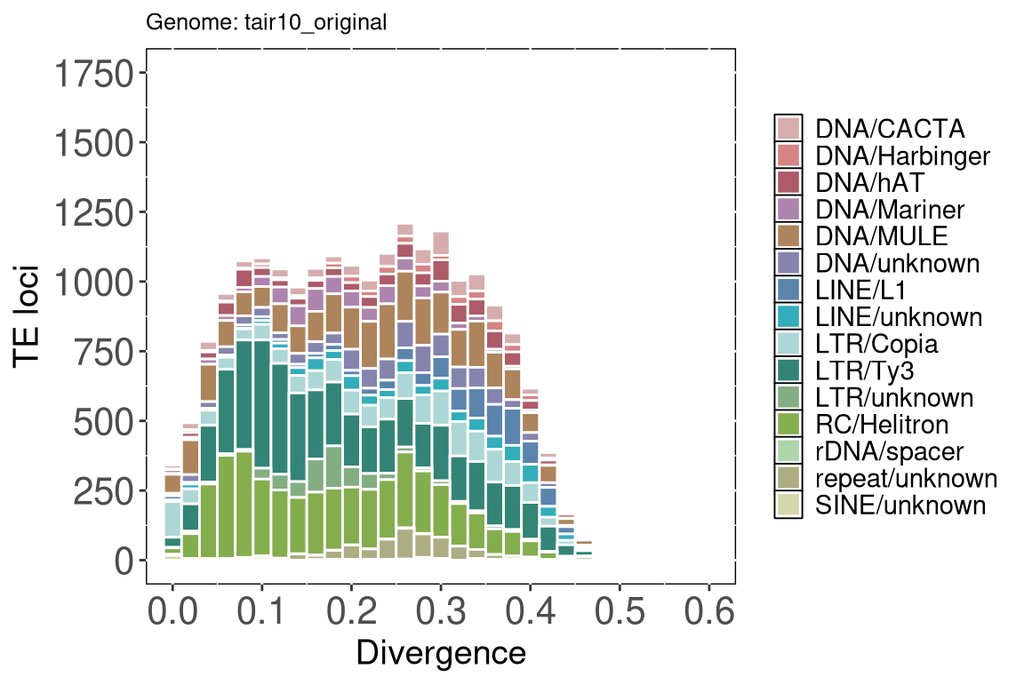

Saved file name: te_loci_divergence_tair10_original.png

### 1.1.3 The distribution of TE loci integrity

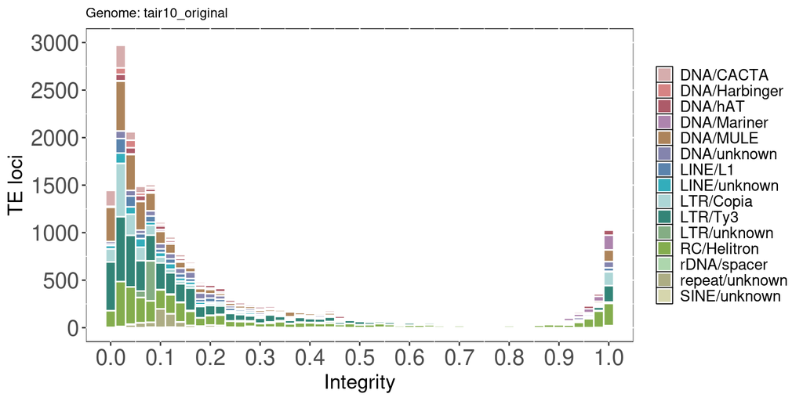

Saved file name: te_loci_integrity_tair10_original.png

### 1.2 Simulated genome

#### 1.2.1 load files

### 1.2.2 The distribution of TE loci divergence

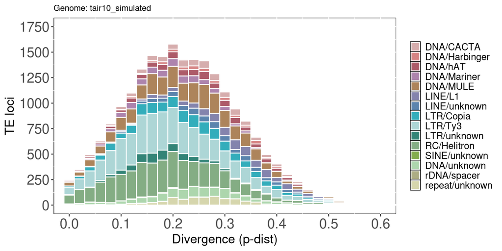

Saved file name: te_loci_divergence_tair10_simulated.png

### 1.2.3 The distribution of TE loci integrity

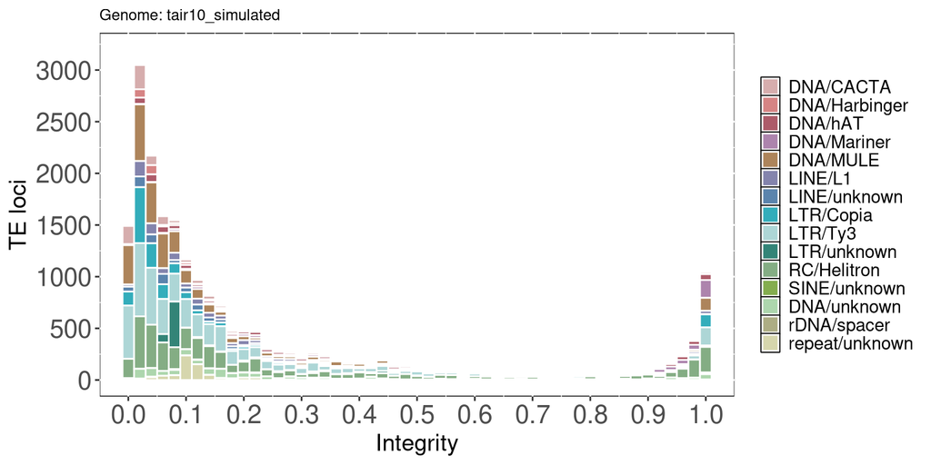

Saved file name: te_loci_integrity_tair10_simulated.png

## 2. Load data for the remaining validation genomes (rice, maize, dm6, danio)

Only the divergence/integrity columns are needed for the correlation analysis below, so these loading chunks skip the superfamily relabelling used for tair10’s distribution plots.

## 3. Analysis 1: correlation between identity and integrity — real vs. mode-2 simulated

For each of the five validation genomes, compute the Pearson and Spearman correlation between TE loci divergence (1 - identity) and integrity, separately for (a) the real/original genome (empirical, from RepeatMasker output) and (b) the mode-2 simulated digital replica. Loci with missing or out-of-range (itg < 0) integrity values are excluded, consistent with the filtering already used for the distribution plots above.

Pearson and Spearman correlation between TE loci divergence and integrity: real (original) vs. mode-2 simulated (digital replica) genomes.

| genome | dataset | n_loci | pearson_r | pearson_ci_low | pearson_ci_high | pearson_p | spearman_rho | spearman_p |
| --- | --- | --- | --- | --- | --- | --- | --- | --- |
| tair10 | Real (original) | 20650 | -0.293 | -0.306 | -0.281 | 0 | -0.207 | 0 |
| tair10 | Mode 2 (simulated) | 21462 | -0.087 | -0.100 | -0.074 | 0 | -0.090 | 0 |
| rice | Real (original) | 363992 | -0.159 | -0.162 | -0.156 | 0 | -0.139 | 0 |
| rice | Mode 2 (simulated) | 371399 | -0.087 | -0.090 | -0.083 | 0 | -0.055 | 0 |
| maize | Real (original) | 1344360 | -0.546 | -0.547 | -0.545 | 0 | -0.536 | 0 |
| maize | Mode 2 (simulated) | 1440211 | -0.461 | -0.462 | -0.460 | 0 | -0.431 | 0 |
| dm6 | Real (original) | 39294 | -0.234 | -0.243 | -0.224 | 0 | -0.174 | 0 |
| dm6 | Mode 2 (simulated) | 40960 | -0.147 | -0.157 | -0.138 | 0 | -0.094 | 0 |
| danio | Real (original) | 4018903 | -0.093 | -0.094 | -0.092 | 0 | -0.070 | 0 |
| danio | Mode 2 (simulated) | 4033429 | -0.116 | -0.117 | -0.115 | 0 | -0.099 | 0 |

### 3.1 Divergence vs. integrity, per species (real vs. mode-2 simulated)

#### tair10

Saved file name: corr_identity_integrity_tair10.png

#### rice

Saved file name: corr_identity_integrity_rice.png

#### maize

Saved file name: corr_identity_integrity_maize.png

#### dm6

Saved file name: corr_identity_integrity_dm6.png

#### danio

Saved file name: corr_identity_integrity_danio.png

## 4. Analysis 2: mode-1 correlation baseline (“by construction ~0”)

Modes 0 and 1 both draw identity and integrity from independent distributions (Gaussian identity, Beta integrity) at simulation time, so any identity-integrity correlation observed under either mode is not designed in - it is the null baseline against which the real/mode-2 correlations in Analysis 1 should be judged. This section uses **mode 1 only**: the `TEgenomeSimulator_tair10_ch1_m0_*` runs originally considered for the mode-0 baseline turned out to have been simulated using a TE mutagenesis table (`TElib_sim_list_mode2.table`) generated by mode 2, not mode 0’s own independent draw, so they are not a valid mode-0 baseline and are excluded. Since a genuine mode-0 run uses the same underlying identity/integrity sampling model as mode 1, mode 1’s result is representative of both. Data reused from the item 29 replicate-run work (no new simulation):

- **Mode 1**: the 4 Fig. 3D identity-SD scenarios x 5 reps each = 20 tair10 (whole-genome) simulations (`TEgenomeSimulator_tair10_sd_scenario{1-4}_rep{1-5}_result`), reported both pooled across all 20 and per scenario (5 reps pooled per scenario), to check that the null correlation holds regardless of the identity-SD setting.

Pearson and Spearman correlation between TE loci divergence and integrity in mode-1 simulated data, where identity and integrity are drawn independently by construction (representative of both modes 0 and 1).

| genome | dataset | n_loci | pearson_r | pearson_ci_low | pearson_ci_high | pearson_p | spearman_rho | spearman_p |
| --- | --- | --- | --- | --- | --- | --- | --- | --- |
| tair10 | Mode 1 (pooled, 20 genomes) | 3714398 | 0.000 | -0.001 | 0.001 | 0.923 | 0.000 | 0.968 |
| tair10 | Mode 1 (scenario 1, pooled 5 reps) | 922587 | -0.002 | -0.004 | 0.000 | 0.075 | -0.001 | 0.232 |
| tair10 | Mode 1 (scenario 2, pooled 5 reps) | 923359 | 0.001 | -0.001 | 0.003 | 0.516 | 0.001 | 0.586 |
| tair10 | Mode 1 (scenario 3, pooled 5 reps) | 923055 | 0.000 | -0.002 | 0.002 | 0.748 | 0.001 | 0.592 |
| tair10 | Mode 1 (scenario 4, pooled 5 reps) | 945397 | 0.000 | -0.002 | 0.002 | 0.761 | 0.000 | 0.819 |

Saved file name: corr_identity_integrity_mode1_baseline.csv

#### Scenario 1

Saved file name: corr_identity_integrity_mode1_scenario1.png

#### Scenario 2

Saved file name: corr_identity_integrity_mode1_scenario2.png

#### Scenario 3

Saved file name: corr_identity_integrity_mode1_scenario3.png

#### Scenario 4

Saved file name: corr_identity_integrity_mode1_scenario4.png

## 5. Analysis 3: non-independence caveat and family-level robustness check

TE loci within a genome are not independent observations: loci belonging to the same TE family share evolutionary history (a single ancestral insertion event, correlated copy number and age), so the per-locus `cor.test()` results in Analyses 1-2 above have an effective sample size well below the raw `n_loci` reported - the same non-independence issue already raised for the Shannon-entropy/Wilcoxon analysis elsewhere in this revision (overlapping/non-independent windows inflating apparent significance). Non-independence inflates the *p-value’s* apparent confidence, not the correlation coefficient itself, so the effect size and its confidence interval - not the p-value - should be treated as the primary evidence from Analyses 1-2.

As a robustness check, each TE family is collapsed to its median divergence and median integrity (one data point per family, regardless of how many loci it contains), and the same Pearson/Spearman test is re-run on those family-level medians, real vs. mode-2, across all 5 species. If the family-level result agrees in sign and rough magnitude with the per-locus result, that is evidence the per-locus correlation is not solely a within-family pseudoreplication artefact.

Family-level robustness check: Pearson/Spearman correlation between median divergence and median integrity per TE family (one point per family, addressing within-family pseudoreplication), real vs. mode-2 simulated.

| genome | dataset | n_families | pearson_r | pearson_ci_low | pearson_ci_high | pearson_p | spearman_rho | spearman_p |
| --- | --- | --- | --- | --- | --- | --- | --- | --- |
| tair10 | Real (original) | 346 | -0.354 | -0.443 | -0.258 | 0 | -0.271 | 0.000 |
| tair10 | Mode 2 (simulated) | 343 | -0.197 | -0.297 | -0.093 | 0 | -0.181 | 0.001 |
| rice | Real (original) | 2050 | -0.292 | -0.331 | -0.252 | 0 | -0.200 | 0.000 |
| rice | Mode 2 (simulated) | 2041 | -0.249 | -0.290 | -0.208 | 0 | -0.166 | 0.000 |
| maize | Real (original) | 1348 | -0.336 | -0.382 | -0.287 | 0 | -0.302 | 0.000 |
| maize | Mode 2 (simulated) | 1348 | -0.319 | -0.366 | -0.270 | 0 | -0.284 | 0.000 |
| dm6 | Real (original) | 639 | -0.306 | -0.375 | -0.234 | 0 | -0.268 | 0.000 |
| dm6 | Mode 2 (simulated) | 619 | -0.309 | -0.378 | -0.236 | 0 | -0.263 | 0.000 |
| danio | Real (original) | 3801 | -0.453 | -0.478 | -0.428 | 0 | -0.451 | 0.000 |
| danio | Mode 2 (simulated) | 3801 | -0.474 | -0.499 | -0.449 | 0 | -0.475 | 0.000 |

Saved file name: corr_identity_integrity_family_level.csv

## 6. Combined summary table

Master summary: Pearson/Spearman correlation between TE loci divergence and integrity across all 5 validation genomes (real vs. mode-2 simulated, per-locus; Analysis 1) and the mode-1 ‘by construction ~0’ baseline (pooled and per identity-SD scenario; Analysis 2). A nominal mode-0 baseline was considered but excluded (Section 4) because the available mode-0 runs had reused a mode-2-derived TE mutagenesis table rather than mode 0’s own independent draw; mode 1 is representative of both modes 0 and 1’s sampling design.

| genome | dataset | n_loci | pearson_r | pearson_ci_low | pearson_ci_high | pearson_p | spearman_rho | spearman_p |
| --- | --- | --- | --- | --- | --- | --- | --- | --- |
| tair10 | Real (original) | 20650 | -0.293 | -0.306 | -0.281 | 0.000 | -0.207 | 0.000 |
| tair10 | Mode 2 (simulated) | 21462 | -0.087 | -0.100 | -0.074 | 0.000 | -0.090 | 0.000 |
| rice | Real (original) | 363992 | -0.159 | -0.162 | -0.156 | 0.000 | -0.139 | 0.000 |
| rice | Mode 2 (simulated) | 371399 | -0.087 | -0.090 | -0.083 | 0.000 | -0.055 | 0.000 |
| maize | Real (original) | 1344360 | -0.546 | -0.547 | -0.545 | 0.000 | -0.536 | 0.000 |
| maize | Mode 2 (simulated) | 1440211 | -0.461 | -0.462 | -0.460 | 0.000 | -0.431 | 0.000 |
| dm6 | Real (original) | 39294 | -0.234 | -0.243 | -0.224 | 0.000 | -0.174 | 0.000 |
| dm6 | Mode 2 (simulated) | 40960 | -0.147 | -0.157 | -0.138 | 0.000 | -0.094 | 0.000 |
| danio | Real (original) | 4018903 | -0.093 | -0.094 | -0.092 | 0.000 | -0.070 | 0.000 |
| danio | Mode 2 (simulated) | 4033429 | -0.116 | -0.117 | -0.115 | 0.000 | -0.099 | 0.000 |
| tair10 | Mode 1 (pooled, 20 genomes) | 3714398 | 0.000 | -0.001 | 0.001 | 0.923 | 0.000 | 0.968 |
| tair10 | Mode 1 (scenario 1, pooled 5 reps) | 922587 | -0.002 | -0.004 | 0.000 | 0.075 | -0.001 | 0.232 |
| tair10 | Mode 1 (scenario 2, pooled 5 reps) | 923359 | 0.001 | -0.001 | 0.003 | 0.516 | 0.001 | 0.586 |
| tair10 | Mode 1 (scenario 3, pooled 5 reps) | 923055 | 0.000 | -0.002 | 0.002 | 0.748 | 0.001 | 0.592 |
| tair10 | Mode 1 (scenario 4, pooled 5 reps) | 945397 | 0.000 | -0.002 | 0.002 | 0.761 | 0.000 | 0.819 |

Saved file name: corr_identity_integrity_master_summary.csv